# ETC5512: Solutions for Tutorial 6

Kate Saunders

Week 6 Combining Australian census and election data

```r
library(tidyverse)
library(sf)

vic_map <- read_sf(here::here("data/vic-july-2018-esri/E_AUGFN3_region.shp")) |>
   # to match up with election data
   mutate(DivisionNm = toupper(Elect_div))

SA1map <- read_sf(here::here("data/Geopackage_2016_EIUWA_for_VIC/census2016_eiuwa_vic_short.gpkg"),
                  layer = "census2016_eiuwa_vic_sa1_short")
```

## 🏂 Exercise 6A

**Integrate data from different sources**

```r
SA1map <- read_sf(here::here("data/Geopackage_2016_EIUWA_for_VIC/census2016_eiuwa_vic_short.gpkg"),
   layer = "census2016_eiuwa_vic_sa1_short"
)
```

```r
SA1map <- SA1map %>%
   mutate(centroid = st_centroid(geom)) %>%
   filter(Median_age_persons != 0)
```

- Plot is made as below. The city region noticeably has regions with higher median weekly personal income.

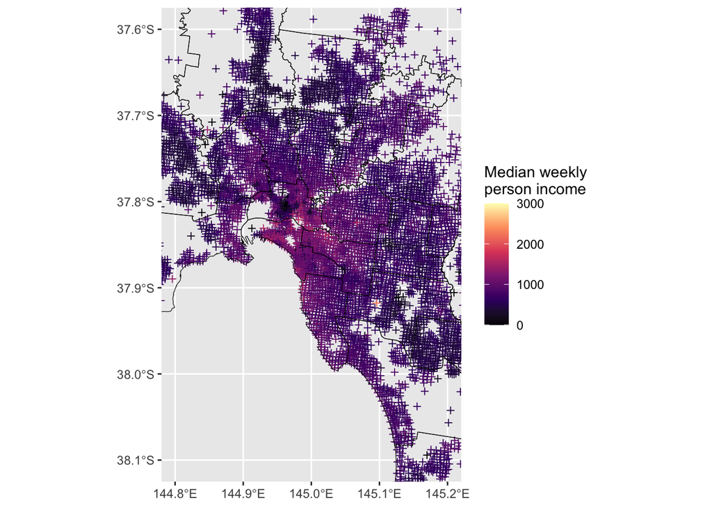

```r
ggplot(SA1map) +
   geom_sf(aes(geometry = centroid, color = Median_tot_prsnl_inc_weekly), shape = 3) +
   geom_sf(data = vic_map, aes(geometry = geometry), fill = "transparent", size = 1.3, color = "black") +
   coord_sf(xlim = c(144.8, 145.2), ylim = c(-38.1, -37.6)) +
   scale_color_viridis_c(name = "Median weekly\nperson income", option = "magma")
```

- We cannot say that those who voted for Green are wealthy individuals from this data alone. There appears to be a large heterogeneity within the electorate (named Melbourne) that the Greens party won.
- Each SA1 region contains approximately the same number of people. Some geographical regions look sparse since the SA1 region is physically large, most notably in the rural areas.
- An ecological fallacy is a mistaken statistical interpretation of data when inferences about the individuals are deduced from the group to which those individuals belong. For example, the Melbourne electorate has many wealthy individuals which make the median weekly personal income high in that electorate. It is wrong to conclude that a typical person selected in the Melbourne electorate will be wealthy.

```r
melb_geometry <- vic_map %>%
   filter(DivisionNm == "MELBOURNE") %>%
   pull(geometry)

MELB_SA1 <- SA1map %>%
   filter(st_intersects(centroid, melb_geometry, sparse = FALSE)[, 1])

fivenum(MELB_SA1$Median_tot_prsnl_inc_weekly)
```

```
## [1]    0.0  589.0  947.0 1130.5 1613.0
```

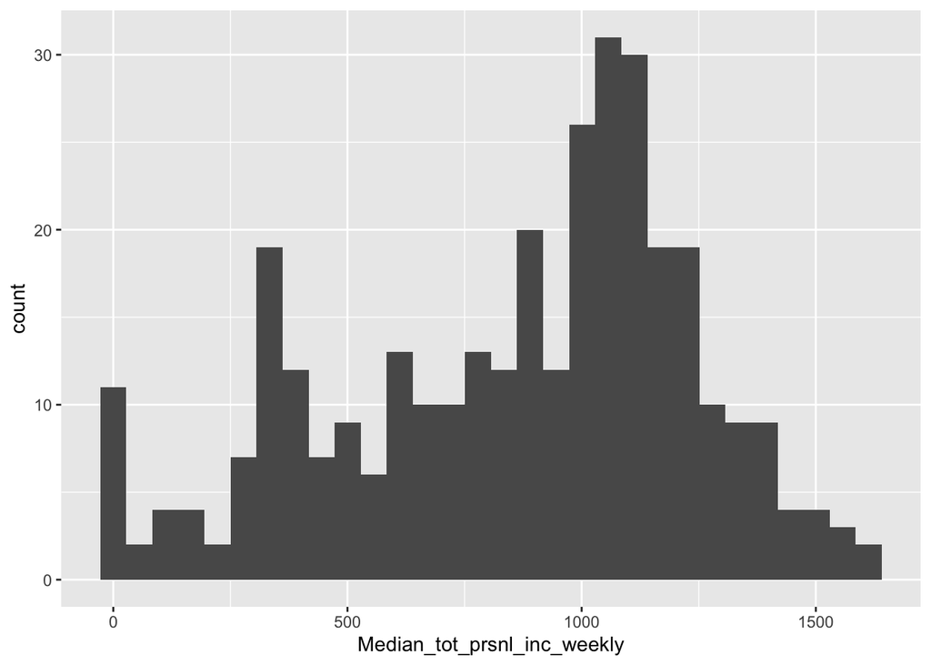

```r
ggplot(MELB_SA1, aes(x = Median_tot_prsnl_inc_weekly)) +
   geom_histogram()
```

## 🗾 Exercise 6B

**Compare with different a layer**

```r
SEDmap <- read_sf(here::here("data/Geopackage_2016_EIUWA_for_VIC/census2016_eiuwa_vic_short.gpkg"),
   layer = "census2016_eiuwa_vic_sed_short"
) %>%
   mutate(centroid = st_centroid(geom))

MELB_SED <- SEDmap %>%
   filter(st_intersects(centroid, melb_geometry, sparse = FALSE)[, 1])
```

```
## st_as_s2(): dropping Z and/or M coordinate
```

```r
fivenum(MELB_SED$Median_tot_prsnl_inc_weekly)
```

```
## [1]  577.0  577.0  816.5 1056.0 1056.0
```

An estimate of the median total person weekly income is 947 dollars using SA1 data and 816.5 dollars using the SED data.

#### Material maintained and updated by Dr. Kate Saunders. Material originally developed by Dr. Emi Tanaka